# Week 2 Assignment

Sung Lee

1/9/2020

[Week 2 Assignment on RPubs](http://rpubs.com/logicalschema/winter_week2)  
[Rmd on Github](https://github.com/logicalschema/r_winter_projects/blob/master/week2.Rmd)

```r
require(plyr)
```

```r
# Load data
# US Births in 1969 - 1988

z_file <- gzcon(url("https://raw.githubusercontent.com/logicalschema/r_winter_projects/master/Birthdays.csv.gz"))
raw_csv <- textConnection(readLines(z_file))
close(z_file)

birthday_data <- read.table(raw_csv, header = TRUE, sep = ",")
head(birthday_data, 5)
```

|  | X | state | year | month | day | date | wday | births |
| --- | --- | --- | --- | --- | --- | --- | --- | --- |
| 1 | 1 | AK | 1969 | 1 | 1 | 1969-01-01 | Wed | 14 |
| 2 | 2 | AL | 1969 | 1 | 1 | 1969-01-01 | Wed | 174 |
| 3 | 3 | AR | 1969 | 1 | 1 | 1969-01-01 | Wed | 78 |
| 4 | 4 | AZ | 1969 | 1 | 1 | 1969-01-01 | Wed | 84 |
| 5 | 5 | CA | 1969 | 1 | 1 | 1969-01-01 | Wed | 824 |

1. Use the summary function to gain an overview of the data set. Then display the mean and median for at least two attributes.

```r
summary(birthday_data)
```

```
##        X              state             year          month
##  Min.   :     1   NY     :  7333   Min.   :1969   Min.   : 1.000
##  1st Qu.: 93217   PA     :  7330   1st Qu.:1973   1st Qu.: 4.000
##  Median :186433   TX     :  7330   Median :1978   Median : 7.000
##  Mean   :186433   CA     :  7325   Mean   :1978   Mean   : 6.522
##  3rd Qu.:279648   MI     :  7323   3rd Qu.:1983   3rd Qu.:10.000
##  Max.   :372864   NJ     :  7321   Max.   :1988   Max.   :12.000
##                   (Other):328902
##       day                date           wday           births
##  Min.   : 1.00   1970-03-01:    70   Fri  :53275   Min.   :   1
##  1st Qu.: 8.00   1970-10-01:    67   Mon  :53242   1st Qu.:  52
##  Median :16.00   1969-03-01:    66   Sat  :53280   Median : 129
##  Mean   :15.74   1969-07-01:    66   Sun  :53240   Mean   : 189
##  3rd Qu.:23.00   1969-10-01:    66   Thurs:53291   3rd Qu.: 223
##  Max.   :31.00   1969-12-01:    65   Tues :53238   Max.   :1779
##                  (Other)   :372464   Wed  :53298
```

###### The mean and median for the year attribute

```r
mean(birthday_data$year)
```

```
## [1] 1978.495
```

```r
median(birthday_data$year)
```

```
## [1] 1978
```

###### The mean and median for the births attribute

```r
mean(birthday_data$births)
```

```
## [1] 189.0409
```

```r
median(birthday_data$births)
```

```
## [1] 129
```

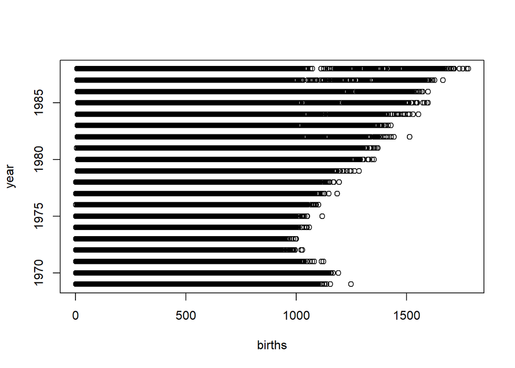

```r
plot(birthday_data[,c("births", "year")])
```

2. Create a new data frame with a subset of the columns and rows. Make sure to rename it.

```r
subset_birthdays = subset(birthday_data, state == "NY" & year >= 1981 & year <= 1988, select=c(state, year, month, births))

tail(subset_birthdays, 5)
```

|  | state | year | month | births |
| --- | --- | --- | --- | --- |
| 372644 | NY | 1988 | 12 | 837 |
| 372695 | NY | 1988 | 12 | 787 |
| 372746 | NY | 1988 | 12 | 817 |
| 372797 | NY | 1988 | 12 | 852 |
| 372848 | NY | 1988 | 12 | 656 |

3. Create new column names for the new data frame.

```r
subset_birthdays <- rename(subset_birthdays, c("state" = "STATE", "year" = "Y", "month" = "M", "births" = "BIRTHS"))

head(subset_birthdays, 5)
```

|  | STATE | Y | M | BIRTHS |
| --- | --- | --- | --- | --- |
| 223877 | NY | 1981 | 1 | 527 |
| 223928 | NY | 1981 | 1 | 614 |
| 223979 | NY | 1981 | 1 | 609 |
| 224030 | NY | 1981 | 1 | 547 |
| 224081 | NY | 1981 | 1 | 637 |

4. Use the summary function to create an overview of your new data frame. Then print the mean and median for the same two attributes. Please compare.

```r
summary(subset_birthdays)
```

```
##      STATE            Y              M              BIRTHS
##  NY     :2922   Min.   :1981   Min.   : 1.000   Min.   :509.0
##  AK     :   0   1st Qu.:1983   1st Qu.: 4.000   1st Qu.:650.0
##  AL     :   0   Median :1984   Median : 7.000   Median :711.0
##  AR     :   0   Mean   :1985   Mean   : 6.523   Mean   :709.1
##  AZ     :   0   3rd Qu.:1987   3rd Qu.:10.000   3rd Qu.:768.0
##  CA     :   0   Max.   :1988   Max.   :12.000   Max.   :933.0
##  (Other):   0
```

```r
mean(subset_birthdays$Y)
```

```
## [1] 1984.501
```

```r
median(subset_birthdays$Y)
```

```
## [1] 1984.5
```

```r
mean(subset_birthdays$BIRTHS)
```

```
## [1] 709.1499
```

```r
median(subset_birthdays$BIRTHS)
```

```
## [1] 711
```

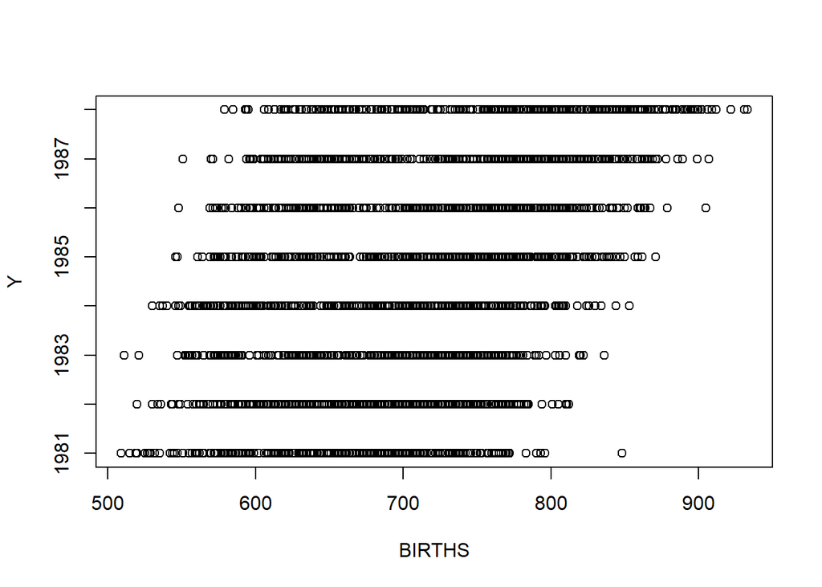

```r
plot(subset_birthdays[,c("BIRTHS", "Y")])
```

The births attribute varied widely from the original data set. The original had a mean: 189 and median: 129. The subset data taken for New York between 1981 and 1988 produced a mean: 709 and median: 711.

5. For at least 3 values in a column please rename so that every value in that column is renamed. For example, suppose I have 20 values of the letter “e” in one column. Rename those values so that all 20 would show as “excellent”.

The following code replaces `NY` with `New York` and prints out the first hundred rows.

```r
subset_birthdays$STATE <- gsub("NY", "New York", subset_birthdays$STATE)

head(subset_birthdays, 100)
```

|  | STATE | Y | M | BIRTHS |
| --- | --- | --- | --- | --- |
| 223877 | New York | 1981 | 1 | 527 |
| 223928 | New York | 1981 | 1 | 614 |
| 223979 | New York | 1981 | 1 | 609 |
| 224030 | New York | 1981 | 1 | 547 |
| 224081 | New York | 1981 | 1 | 637 |
| 224132 | New York | 1981 | 1 | 670 |
| 224183 | New York | 1981 | 1 | 712 |
| 224234 | New York | 1981 | 1 | 642 |
| 224285 | New York | 1981 | 1 | 643 |
| 224336 | New York | 1981 | 1 | 608 |

[output cut: 90 more lines]

6. Display enough rows to see examples of all of steps 1-5 above.

7. BONUS – place the original .csv in a github file and have R read from the link. This will be a very useful skill as you progress in your data science education and career.

The following code block implements the task. I zipped the csv file to make transport quicker.

```r
z_file <- gzcon(url("https://raw.githubusercontent.com/logicalschema/r_winter_projects/master/Birthdays.csv.gz"))
raw_csv <- textConnection(readLines(z_file))
close(z_file)

birthday_data <- read.table(raw_csv, header = TRUE, sep = ",")
```